# Linear Regression · TuringGLM.jl

[GitHub](https://github.com/TuringLang/TuringGLM.jl)[](https://github.com/TuringLang/TuringGLM.jl/blob/main/docs/src/tutorials/linear_regression.jl)

Let's cover **Linear Regression** with a famous dataset called `kidiq` (Gelman & Hill, 2007), which is data from a survey of adult American women and their respective children. Dated from 2007, it has 434 observations and 4 variables:

- `kid_score`: child's IQ
- `mom_hs`: binary/dummy (0 or 1) if the child's mother has a high school diploma
- `mom_iq`: mother's IQ
- `mom_age`: mother's age

For the purposes of this tutorial, we download the dataset from the TuringGLM repository:

```julia
using CSV
```

```julia
using DataFrames
```

```julia
using TuringGLM
```

```julia
url = "https://github.com/TuringLang/TuringGLM.jl/raw/main/data/kidiq.csv";
```

```julia
kidiq = CSV.read(download(url), DataFrame)
```

|  | kid_score | mom_hs | mom_iq | mom_age |
| --- | --- | --- | --- | --- |
| 1 | 65 | 1 | 121.118 | 27 |
| 2 | 98 | 1 | 89.3619 | 25 |
| 3 | 85 | 1 | 115.443 | 27 |
| 4 | 83 | 1 | 99.4496 | 25 |
| 5 | 115 | 1 | 92.7457 | 27 |
| 6 | 98 | 0 | 107.902 | 18 |
| 7 | 69 | 1 | 138.893 | 20 |
| 8 | 106 | 1 | 125.145 | 23 |
| 9 | 102 | 1 | 81.6195 | 24 |
| 10 | 95 | 1 | 95.0731 | 19 |
| ... |  |  |  |  |
| 434 | 70 | 1 | 91.2533 | 25 |

Using `kid_score` as dependent variable and `mom_hs` along with `mom_iq` as independent variables with a moderation (interaction) effect:

```julia
fm = @formula(kid_score ~ mom_hs * mom_iq)
```

```
FormulaTerm
Response:
  kid_score(unknown)
Predictors:
  mom_hs(unknown)
  mom_iq(unknown)
  mom_hs(unknown) & mom_iq(unknown)
```

Next, we instantiate our model with `turing_model` without specifying any model, thus the default model will be used (`model=Normal`):

```julia
model = turing_model(fm, kidiq);
```

```julia
n_samples = 2_000;
```

This model is a valid Turing model, which we can pass to the default `sample` function from Turing to get our parameter estimates. We use the `NUTS` sampler with 2000 samples.

```julia
chns = sample(model, NUTS(), n_samples);
```

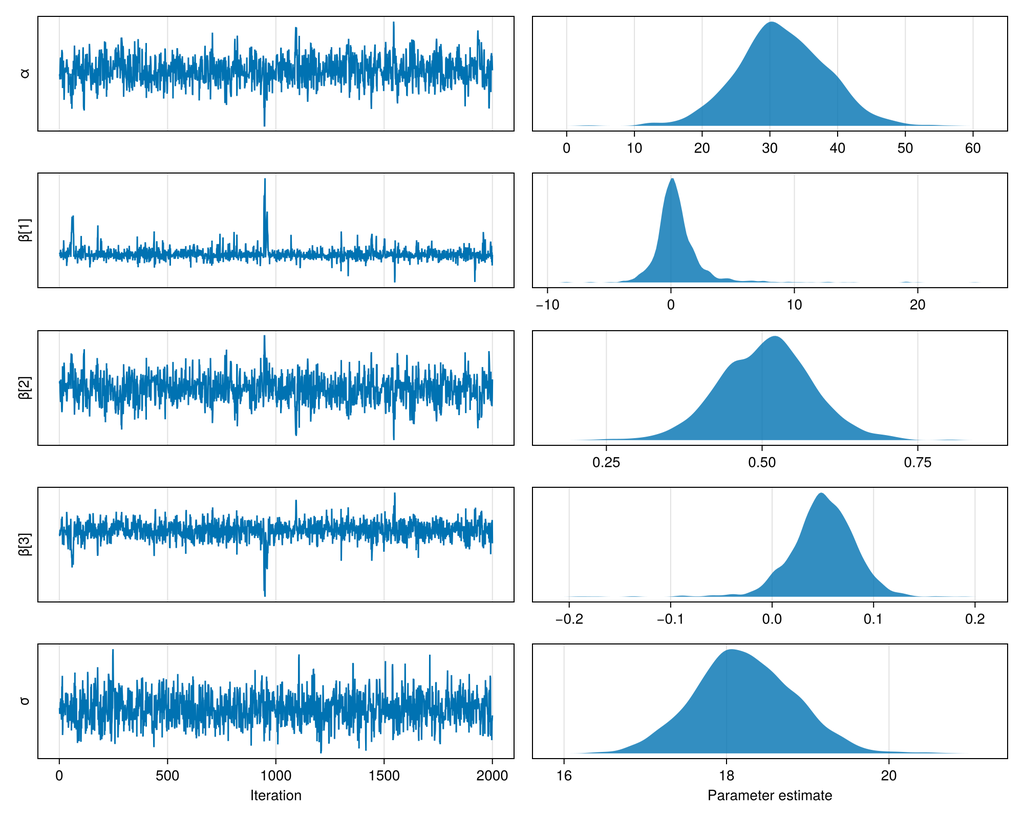

```julia
plot_chains(chns)
```

## References

Gelman, A., & Hill, J. (2007). Data analysis using regression and multilevel/hierarchical models. Cambridge university press.